# Regression tutorial

## Stepwise regression: Least Angle Regression

Stepwise regression refers to automated procedures for choosing the next variable to be included in the regression model. We have for example seen that R contains a step() function for stepwise regression in OLS. This procedure is however ‘greedy’ in that it decides to include or exclude variables based on GOF measures (like $R^2$, AIC, BIC etc).

There might be cases in which other considerations play an important role. We could for example like to include some variables that are related, together into the model. The stepwise regression will have the tendency in this case to exclude some of these variables as the inclusion of a second or successive variable might not have a large enough impact on the model performance due to correlation effects. There are stepwise regression procedures that are add variables in a piecewise manner. An example is the Least Angle Regression. The package lars contains this procedure. It is good to note that this prcoedure is implemented in an efficient way and takes optimal steps rather than tiny steps together with evaulation at a time (we have seen an example in the lasso regression).

```r
X <- model.matrix(rate~.,data=MurderRates)
lar_mod<-lars(X, MurderRates$rate, type = "lasso")
coef(lar_mod) #Coefficients
```

```
##      (Intercept) convictions executions         time    income       lfp
## [1,]           0    0.000000  0.0000000  0.000000000  0.000000 0.0000000
## [2,]           0    0.000000  0.0000000  0.000000000  0.000000 0.0000000
## [3,]           0    0.000000  0.0000000  0.000000000  0.000000 0.0000000
## [4,]           0    0.000000  0.0000000 -0.002298863  0.000000 0.0000000
## [5,]           0    0.000000  0.0000000 -0.005804949 -0.384036 0.0000000
## [6,]           0   -3.187847  0.0000000 -0.011551769 -1.049169 0.0000000
## [7,]           0   -3.547923  0.9618214 -0.012520746 -1.198072 0.0000000
## [8,]           0   -4.339377  2.8527597 -0.015470155 -2.500133 0.1935676
##        noncauc southernyes
## [1,]  0.000000   0.0000000
## [2,]  0.000000   0.5625381
## [3,]  9.569214   2.8374790
## [4,] 10.649706   2.9524144
## [5,] 11.802471   2.9698053
## [6,] 12.427942   3.0879160
## [7,] 12.297900   3.0826606
## [8,] 10.399032   3.2621653
```

```r
lar_mod$R2 #Coefficient of determination per step
```

```
##          0          1          2          3          4          5          6
## 0.00000000 0.08900954 0.57612603 0.61438489 0.66187303 0.72588918 0.73149721
##          7
## 0.74590161
```

```r
summary(lar_mod)
```

```
## LARS/LASSO
## Call: lars(x = X, y = MurderRates$rate, type = "lasso")
##   Df    Rss      Cp
## 0  1 856.67 99.6774
## 1  2 780.42 89.0668
## 2  3 363.12 22.0534
## 3  4 330.34 18.6329
## 4  5 289.66 13.9050
## 5  6 234.82  6.8353
## 6  7 230.02  8.0408
## 7  8 217.68  8.0000
```

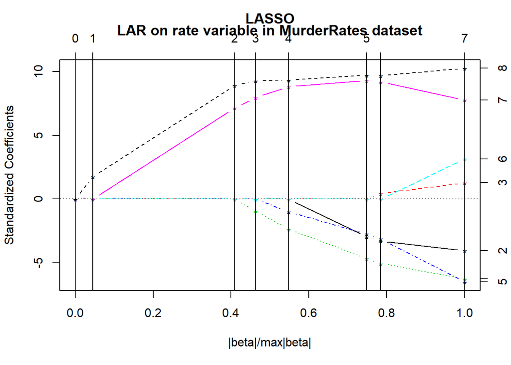

```r
plot(lar_mod,main="LAR on rate variable in MurderRates dataset")
```

## Local and kernel regression

In case of a local regression a line is fitted locally, most commonly per point. The problem in this case is to obtain $\beta(x)$ for which the quantity $\sum_{i=1}^{n}w_i(x)(y_i-X\beta(x))$ is minimized. Here it is assumed that $w_i(x)$ is proportional to some Kernel function $K(x_i,x)$. The Kernel function $\left(1-\left(\frac{|X_i-X_0|}{h}\right)^3\right)^3$ is an example of a common choice. How smooth the fit will be depends on the span, a higher span takes a wider neighborhood into account and therefore yields a smoother fit. Loess and lowess regressions are examples of local regressions.

More generally note that these are examples of kernel regressions. Kernel regression is a non-parametric technique for different approaches that estimatee the function $m$ in the relation $E(Y|X)=m(X)$ using kernel functions. In the above case, the function $m$ was constructed as a locally weighted average using a kernel for weights.

Below we show an example of local regression and one kernel regression approach ( Nadaraya-Watson).

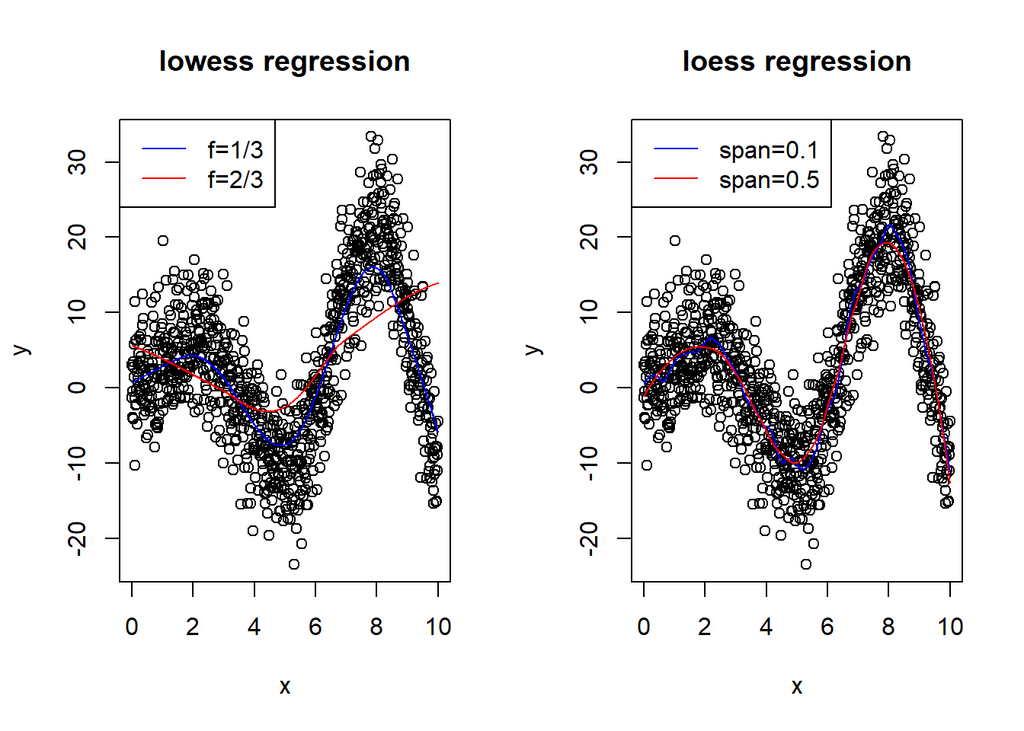

```r
x=seq(0,10,0.01)
y=1.2+2.4*(x*sin(x))+rnorm(length(x),0,5)

par(mfrow=c(1,2))

#argument f gives the smoother span, a larger value will yield a smoother fit.
plot(x,y,main="lowess regression")
lines(lowess(x,y,f=1/3),lty=1,col="blue")
lines(lowess(x,y,f=2/3),lty=1,col="red")
legend("topleft",legend=c("f=1/3","f=2/3"),col=c("blue","red"),lty=1)

#loess is another implementation in R that is newer and more flexible. Note that loess and lowess follow a different syntax.
plot(x,y,main="loess regression")
lines(x,loess(y~x,span=0.10)$fitted,lty=1,col="blue")
lines(x,loess(y~x,span=0.50)$fitted,lty=1,col="red")
legend("topleft",legend=c("span=0.1","span=0.5"),col=c("blue","red"),lty=1)
```

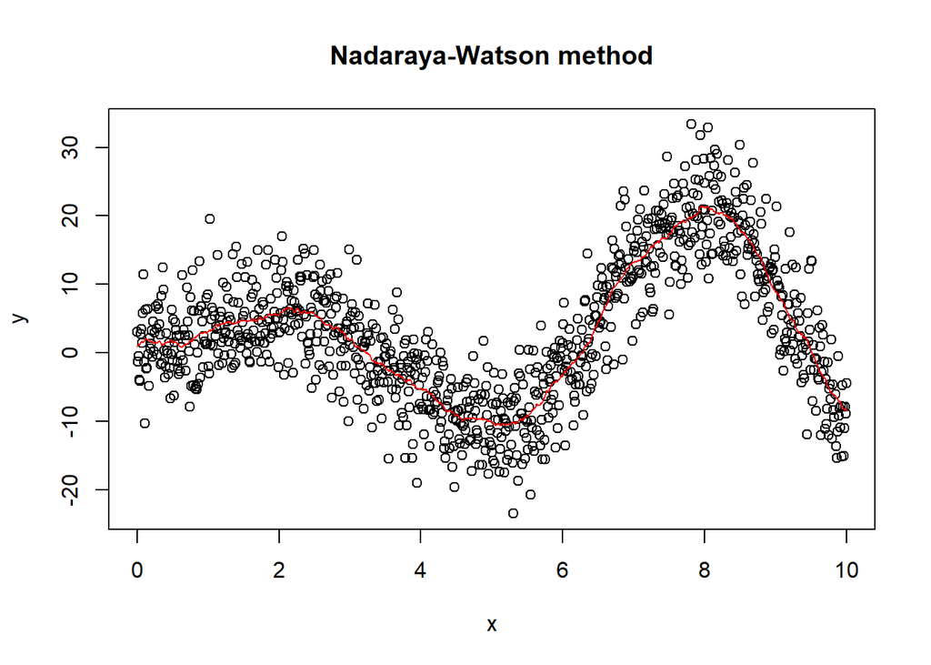

```r
#Additionally we look at the Nadaraya-Watson kernel smoother method
require(stats)
par(mfrow=c(1,1))
plot(x,y,main="Nadaraya-Watson method")
lines(ksmooth(x,y),col="red")
```

## Main References

- Econometric methods with applications in business and economics, C Heij et al, 2004
- Elements of Statistical Learning (2nd edition), T Hastie et al, 2016
- Principles of econometrics with R, C Colonescu, 2016
- Machine Learning Foundations: A case study approach, University of Washington (Coursera)
- Various packages and corresponding documentation listed used in the above analyses (lars, glmnet, MASS, ridge, AER etc)